# 1.Problem 1

## Wholesale Customers Analysis (Download Data)

Problem Statement: A wholesale distributor operating in different regions of Portugal has information on annual spending of several items in their stores across different regions and channels. The data consists of 440 large retailers’ annual spending on 6 different varieties of products in 3 different regions (Lisbon, Oporto, Other) and across different sales channel (Hotel, Retail).

### Details of the problem.

Data consists retailers;440.

product varieties;6.

regions;3 (Lisbon,Oporto,Other)

sales channels;2 (Hotel,Retail)

product varieties consists

Fresh

Milk

Grocery

Frozen

Detergents_Paper

Delicatessen

```python
# Libraries to help with reading and manipulating data
import numpy as np
import pandas as pd

# Libraries to help with data visualization
import matplotlib.pyplot as plt
import seaborn as sns
import statsmodels.api as sm
import scipy.stats as stats
# Command to tell Python to actually display the graphs
%matplotlib inline
pd.set_option("display.float_format", lambda x: "%.2f" % x) #to display values upto 2 decimal places
```

```python
from google.colab import files
files.upload()
```

Upload widget is only available when the cell has been executed in the current browser session. Please rerun this cell to enable.

```
Saving Wholesale+Customers+Data.csv to Wholesale+Customers+Data.csv
```

[output not shown]

```python
df=pd.read_csv('Wholesale+Customers+Data.csv')
```

```python
df.head(5)
```

|  | Buyer/Spender | Channel | Region | Fresh | Milk | Grocery | Frozen | Detergents_Paper | Delicatessen |
| --- | --- | --- | --- | --- | --- | --- | --- | --- | --- |
| 0 | 1 | Retail | Other | 12669 | 9656 | 7561 | 214 | 2674 | 1338 |
| 1 | 2 | Retail | Other | 7057 | 9810 | 9568 | 1762 | 3293 | 1776 |
| 2 | 3 | Retail | Other | 6353 | 8808 | 7684 | 2405 | 3516 | 7844 |
| 3 | 4 | Hotel | Other | 13265 | 1196 | 4221 | 6404 | 507 | 1788 |
| 4 | 5 | Retail | Other | 22615 | 5410 | 7198 | 3915 | 1777 | 5185 |

The first 5 rows of the data to check the details

# 1.1.Use methods of descriptive statistics to summarize data. Which Region and which Channel spent the most? Which Region and which Channel spent the least?

```python
df.info()
```

```
<class 'pandas.core.frame.DataFrame'>
RangeIndex: 440 entries, 0 to 439
Data columns (total 9 columns):
 #   Column            Non-Null Count  Dtype
---  ------            --------------  -----
 0   Buyer/Spender     440 non-null    int64
 1   Channel           440 non-null    object
 2   Region            440 non-null    object
 3   Fresh             440 non-null    int64
 4   Milk              440 non-null    int64
 5   Grocery           440 non-null    int64
 6   Frozen            440 non-null    int64
 7   Detergents_Paper  440 non-null    int64
 8   Delicatessen      440 non-null    int64
dtypes: int64(7), object(2)
memory usage: 31.1+ KB
```

Info function is used to see the data types, no of columns and rows.

```python
df.isnull().sum()
```

```
Buyer/Spender       0
Channel             0
Region              0
Fresh               0
Milk                0
Grocery             0
Frozen              0
Detergents_Paper    0
Delicatessen        0
dtype: int64
```

This shows there are no null values in data.

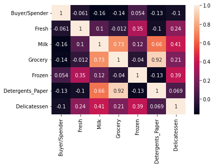

```python
sns.heatmap(df.corr(),annot=True);
```

The correlation of the data can be seen from the above plot.

```python
df_des=df.describe(include='all')
df_des.loc[('Total'), :] = df_des.sum();
df_des
```

|  | Buyer/Spender | Channel | Region | Fresh | Milk | Grocery | Frozen | Detergents_Paper | Delicatessen |
| --- | --- | --- | --- | --- | --- | --- | --- | --- | --- |
| count | 440.00 | 440 | 440 | 440.00 | 440.00 | 440.00 | 440.00 | 440.00 | 440.00 |
| unique | NaN | 2 | 3 | NaN | NaN | NaN | NaN | NaN | NaN |
| top | NaN | Hotel | Other | NaN | NaN | NaN | NaN | NaN | NaN |
| freq | NaN | 298 | 316 | NaN | NaN | NaN | NaN | NaN | NaN |
| mean | 220.50 | NaN | NaN | 12000.30 | 5796.27 | 7951.28 | 3071.93 | 2881.49 | 1524.87 |
| std | 127.16 | NaN | NaN | 12647.33 | 7380.38 | 9503.16 | 4854.67 | 4767.85 | 2820.11 |
| min | 1.00 | NaN | NaN | 3.00 | 55.00 | 3.00 | 25.00 | 3.00 | 3.00 |
| 25% | 110.75 | NaN | NaN | 3127.75 | 1533.00 | 2153.00 | 742.25 | 256.75 | 408.25 |
| 50% | 220.50 | NaN | NaN | 8504.00 | 3627.00 | 4755.50 | 1526.00 | 816.50 | 965.50 |
| 75% | 330.25 | NaN | NaN | 16933.75 | 7190.25 | 10655.75 | 3554.25 | 3922.00 | 1820.25 |
| max | 440.00 | NaN | NaN | 112151.00 | 73498.00 | 92780.00 | 60869.00 | 40827.00 | 47943.00 |
| Total | 1890.16 | NaN | NaN | 165807.13 | 99519.89 | 128241.69 | 75083.11 | 53914.60 | 55924.98 |

```python
Spending=df.groupby(by=['Region','Channel'])['Buyer/Spender'].count()
Spending
```

```
Region  Channel
Lisbon  Hotel       59
        Retail      18
Oporto  Hotel       28
        Retail      19
Other   Hotel      211
        Retail     105
Name: Buyer/Spender, dtype: int64
```

The above information gives most and least values across the region and channel.

```python
Max_Spending=df.groupby(by=['Region','Channel'])['Fresh','Milk','Grocery','Frozen','Detergents_Paper','Delicatessen'].max()
Max_Spending
```

| Region | Channel | Fresh | Milk | Grocery | Frozen | Detergents_Paper | Delicatessen |
| --- | --- | --- | --- | --- | --- | --- | --- |
| Lisbon | Hotel | 56083 | 23527 | 16966 | 18711 | 5828 | 6854 |
|  | Retail | 20782 | 28326 | 39694 | 8321 | 19410 | 6372 |
| Oporto | Hotel | 32717 | 16784 | 13626 | 60869 | 1679 | 5609 |
|  | Retail | 27082 | 25071 | 67298 | 11559 | 38102 | 3508 |
| Other | Hotel | 112151 | 43950 | 21042 | 36534 | 6907 | 47943 |
|  | Retail | 44466 | 73498 | 92780 | 8132 | 40827 | 16523 |

The above table gives maximum spendings of products across region and channel.

```python
Min_Spending=df.groupby(by=['Region','Channel'])['Fresh','Milk','Grocery','Frozen','Detergents_Paper','Delicatessen'].min()
Min_Spending
```

| Region | Channel | Fresh | Milk | Grocery | Frozen | Detergents_Paper | Delicatessen |
| --- | --- | --- | --- | --- | --- | --- | --- |
| Lisbon | Hotel | 514 | 258 | 489 | 91 | 5 | 7 |
|  | Retail | 18 | 2527 | 5265 | 61 | 788 | 120 |
| Oporto | Hotel | 3 | 333 | 1330 | 264 | 15 | 51 |
|  | Retail | 161 | 928 | 2743 | 131 | 332 | 59 |
| Other | Hotel | 3 | 55 | 3 | 25 | 3 | 3 |
|  | Retail | 23 | 1124 | 4523 | 33 | 523 | 3 |

The above table gives minimum spendings of products across region and channel.

## Similarly from the above results we can conclude that under region other hotal only has got least spendings.

```python
pd.crosstab(df['Region'],df['Channel'] )
```

| Channel Region | Hotel | Retail |
| --- | --- | --- |
| Lisbon | 59 | 18 |
| Oporto | 28 | 19 |
| Other | 211 | 105 |

The above cross tab gives most and least values across the region and channel.

```python
df.Channel.value_counts()
```

```
Hotel     298
Retail    142
Name: Channel, dtype: int64
```

Most and least spendings of Channel:

```python
df.Region.value_counts()
```

```
Other     316
Lisbon     77
Oporto     47
Name: Region, dtype: int64
```

Most and least spendings of Region:

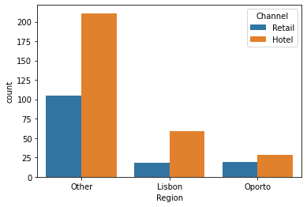

```python
sns.countplot(x="Region", hue="Channel", data=df)
```

# As we can see from the graph and the value count method in region other has got most spendings and oporto has the least, similarly in channels hotel has has got more spendings and retail has got least as per thier value counts.

# 1.2.There are 6 different varieties of items that are considered. Describe and comment/explain all the varieties across Region and Channel? Provide a detailed justification for your answer.

```python
df.groupby(by=['Region','Channel'])['Fresh','Milk','Grocery','Frozen','Detergents_Paper','Delicatessen'].describe().T
```

|  | Region Channel | Lisbon Hotel | Lisbon Retail | Oporto Hotel | Oporto Retail | Other Hotel | Other Retail |
| --- | --- | --- | --- | --- | --- | --- | --- |
| Fresh | count | 59.00 | 18.00 | 28.00 | 19.00 | 211.00 | 105.00 |
|  | mean | 12902.25 | 5200.00 | 11650.54 | 7289.79 | 13878.05 | 9831.50 |
|  | std | 12342.01 | 5415.52 | 8969.36 | 6867.93 | 14746.57 | 9635.39 |
|  | min | 514.00 | 18.00 | 3.00 | 161.00 | 3.00 | 23.00 |
|  | 25% | 4437.50 | 2378.25 | 4938.25 | 2368.00 | 3702.50 | 2343.00 |
|  | 50% | 8656.00 | 2926.00 | 9787.00 | 6468.00 | 9612.00 | 7362.00 |
|  | 75% | 18135.00 | 5988.00 | 17031.50 | 9162.00 | 18821.00 | 15076.00 |
|  | max | 56083.00 | 20782.00 | 32717.00 | 27082.00 | 112151.00 | 44466.00 |
| Milk | count | 59.00 | 18.00 | 28.00 | 19.00 | 211.00 | 105.00 |
|  | mean | 3870.20 | 10784.00 | 2304.25 | 9190.79 | 3486.98 | 10981.01 |
|  | std | 4298.32 | 6609.22 | 2968.63 | 6611.35 | 4508.51 | 10574.83 |
|  | min | 258.00 | 2527.00 | 333.00 | 928.00 | 55.00 | 1124.00 |
|  | 25% | 1071.00 | 6253.25 | 1146.00 | 4148.50 | 1188.50 | 6128.00 |
|  | 50% | 2280.00 | 8866.00 | 1560.50 | 6817.00 | 2247.00 | 7845.00 |
|  | 75% | 4995.50 | 13112.25 | 2344.75 | 13127.50 | 4205.00 | 11114.00 |
|  | max | 23527.00 | 28326.00 | 16784.00 | 25071.00 | 43950.00 | 73498.00 |
| Grocery | count | 59.00 | 18.00 | 28.00 | 19.00 | 211.00 | 105.00 |
|  | mean | 4026.14 | 18471.94 | 4395.50 | 16326.32 | 3886.73 | 15953.81 |
|  | std | 3629.64 | 10414.69 | 3048.30 | 14035.45 | 3593.51 | 12298.94 |
|  | min | 489.00 | 5265.00 | 1330.00 | 2743.00 | 3.00 | 4523.00 |
|  | 25% | 1620.00 | 10634.25 | 2373.75 | 9318.50 | 1666.00 | 9170.00 |
|  | 50% | 2576.00 | 16106.00 | 3352.00 | 12469.00 | 2642.00 | 12121.00 |
|  | 75% | 5172.50 | 23478.75 | 5527.50 | 19785.50 | 4927.50 | 19805.00 |
|  | max | 16966.00 | 39694.00 | 13626.00 | 67298.00 | 21042.00 | 92780.00 |
| Frozen | count | 59.00 | 18.00 | 28.00 | 19.00 | 211.00 | 105.00 |
|  | mean | 3127.32 | 2584.11 | 5745.04 | 1540.58 | 3656.90 | 1513.20 |
|  | std | 3276.46 | 2424.77 | 11454.48 | 2473.27 | 4956.59 | 1504.50 |
|  | min | 91.00 | 61.00 | 264.00 | 131.00 | 25.00 | 33.00 |
|  | 25% | 966.00 | 923.50 | 962.25 | 639.50 | 779.00 | 437.00 |
|  | 50% | 1859.00 | 1522.00 | 2696.50 | 934.00 | 1960.00 | 1059.00 |
|  | 75% | 4479.00 | 3843.00 | 4617.00 | 1410.00 | 4542.50 | 2194.00 |
|  | max | 18711.00 | 8321.00 | 60869.00 | 11559.00 | 36534.00 | 8132.00 |
| Detergents_Paper | count | 59.00 | 18.00 | 28.00 | 19.00 | 211.00 | 105.00 |
|  | mean | 950.53 | 8225.28 | 482.71 | 8410.26 | 786.68 | 6899.24 |
|  | std | 1305.91 | 5515.88 | 425.31 | 8286.75 | 1099.97 | 6022.09 |
|  | min | 5.00 | 788.00 | 15.00 | 332.00 | 3.00 | 523.00 |
|  | 25% | 237.00 | 4818.25 | 182.75 | 3900.00 | 176.50 | 3537.00 |
|  | 50% | 412.00 | 6177.00 | 325.00 | 6236.00 | 375.00 | 5121.00 |
|  | 75% | 874.00 | 11804.75 | 707.00 | 9837.50 | 948.50 | 7677.00 |
|  | max | 5828.00 | 19410.00 | 1679.00 | 38102.00 | 6907.00 | 40827.00 |
| Delicatessen | count | 59.00 | 18.00 | 28.00 | 19.00 | 211.00 | 105.00 |
|  | mean | 1197.15 | 1871.94 | 1105.89 | 1239.00 | 1518.28 | 1826.21 |
|  | std | 1219.95 | 1626.49 | 1056.78 | 1065.44 | 3663.18 | 2119.05 |
|  | min | 7.00 | 120.00 | 51.00 | 59.00 | 3.00 | 3.00 |
|  | 25% | 374.00 | 746.00 | 567.25 | 392.50 | 378.50 | 545.00 |
|  | 50% | 749.00 | 1414.00 | 883.00 | 1037.00 | 823.00 | 1386.00 |
|  | 75% | 1621.50 | 2456.50 | 1146.00 | 1815.00 | 1582.00 | 2158.00 |
|  | max | 6854.00 | 6372.00 | 5609.00 | 3508.00 | 47943.00 | 16523.00 |

The above output shows products five point summary across region and channel.

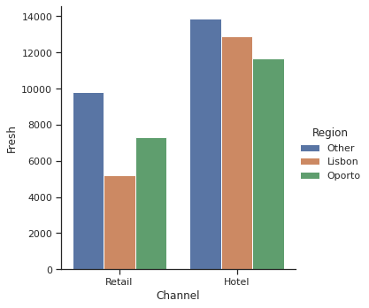

```python
sns.set(style='ticks', color_codes=True)
sns.catplot(x='Channel', y='Fresh',hue='Region',kind='bar',ci=None,data=df)
```

From the above evidances we can say the find the 5 point summary of Fresh cross region and channel.

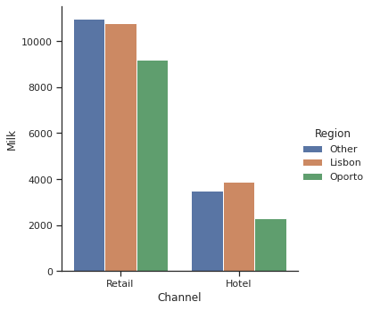

```python
sns.set(style='ticks', color_codes=True)
sns.catplot(x='Channel', y='Milk',hue='Region',kind='bar',ci=None,data=df)
```

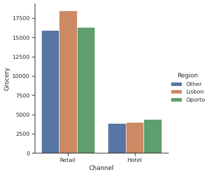

```python
sns.set(style='ticks', color_codes=True)
sns.catplot(x='Channel', y='Grocery',hue='Region',kind='bar',ci=None,data=df)
```

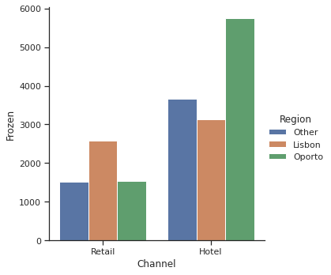

```python
sns.set(style='ticks', color_codes=True)
sns.catplot(x='Channel', y='Frozen',hue='Region',kind='bar',ci=None,data=df)
```

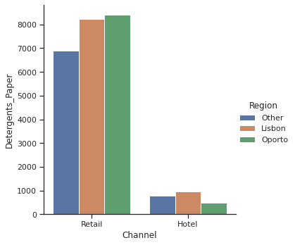

```python
sns.set(style='ticks', color_codes=True)
sns.catplot(x='Channel', y='Detergents_Paper',hue='Region',kind='bar',ci=None,data=df)
```

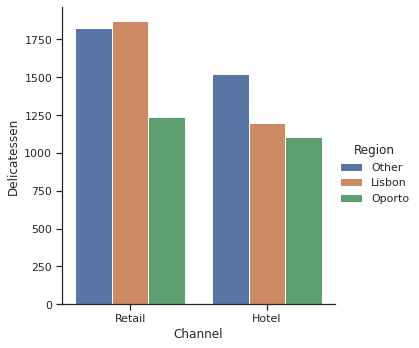

```python
sns.set(style='ticks', color_codes=True)
sns.catplot(x='Channel', y='Delicatessen',hue='Region',kind='bar',ci=None,data=df)
```

## As you can see the above describe methods explains all 6 different varieties across the region and channel.

## 1.3 On the basis of a descriptive measure of variability, which item shows the most inconsistent behaviour? Which items show the least inconsistent behaviour?

```python
products=df.iloc[:,2:9]
```

```python
standard_deviation=round(products.std(),2)
standard_deviation
```

```
Fresh              12647.33
Milk                7380.38
Grocery             9503.16
Frozen              4854.67
Detergents_Paper    4767.85
Delicatessen        2820.11
dtype: float64
```

as per the above data Fresh more standard deviation so it is inconsistent on the other hand delicatessen has least standard deviation so it is consistent.

```python
Mean_A=products.mean()
Mean_A
```

```
Fresh              12000.30
Milk                5796.27
Grocery             7951.28
Frozen              3071.93
Detergents_Paper    2881.49
Delicatessen        1524.87
dtype: float64
```

as per the above data Fresh more standard deviation so it is inconsistent on the other hand delicatessen has least standard deviation so it is consistent.

```python
products_CV=standard_deviation/Mean_A
products_CV
```

```
Fresh              1.05
Milk               1.27
Grocery            1.20
Frozen             1.58
Detergents_Paper   1.65
Delicatessen       1.85
dtype: float64
```

The above CV (Coeffient of variation)table, we can say that, Fresh show the more consistent behavior, as the coefficient of variation is the lowest for it. On the other hand, Under Delicatessen show the inconsistent behavior as the CV is the highest but this is the wrong result as there are outliers.

## 1.4.Are there any outliers in the data? Back up your answer with a suitable plot/technique with the help of detailed comments.

```python
Skewness = pd.DataFrame({'Skewness' : [stats.skew(df.Fresh),stats.skew(df.Milk),stats.skew(df.Grocery),stats.skew(df.Frozen),stats.skew(df.Detergents_Paper),stats.skew(df.Delicatessen)]},
                        index=['Fresh','Milk','Grocery','Frozen','Detergents_paper','Delicatessen'])  # Measure the skeweness of the required columns
Skewness
```

|  | Skewness |
| --- | --- |
| Fresh | 2.55 |
| Milk | 4.04 |
| Grocery | 3.58 |
| Frozen | 5.89 |
| Detergents_paper | 3.62 |
| Delicatessen | 11.11 |

Skewness shows how symmetrical is the data as we can see Fresh is more symmetric where as Delicatessen is least.

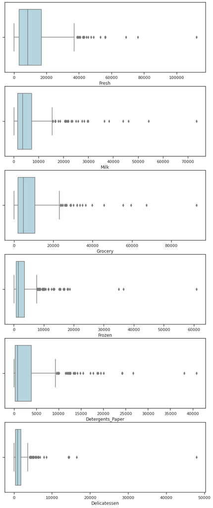

```python
plt.figure(figsize= (10,25))
plt.subplot(6,1,1)
sns.boxplot(x= df.Fresh, color='lightblue')

plt.subplot(6,1,2)
sns.boxplot(x= df.Milk, color='lightblue')

plt.subplot(6,1,3)
sns.boxplot(x= df.Grocery, color='lightblue')

plt.subplot(6,1,4)
sns.boxplot(x= df.Frozen, color='lightblue')

plt.subplot(6,1,5)
sns.boxplot(x= df.Detergents_Paper, color='lightblue')

plt.subplot(6,1,6)
sns.boxplot(x= df.Delicatessen, color='lightblue')

plt.show()
```

## 1.5 On the basis of your analysis, what are your recommendations for the business? How can your analysis help the business to solve its problem? Answer from the business perspective